SV

Assumptions:

1. unzipped data file is located in current working directory
2. packages installed: ggplot2, dplyr

===========================================================

Set global options and path for figures:

```r
knitr::opts_chunk$set(fig.width=12, fig.height=8, fig.path='figs/')
```

============================================================

# Part 1: Load and process the data for analysis.

1. Load using read.csv
2. Convert date to “date” type
3. head() gives a peak at the data

```r
am_data<-read.csv("activity.csv")
am_data$date<-as.Date(am_data$date)

head(am_data)
```

```
##   steps       date interval
## 1    NA 2012-10-01        0
## 2    NA 2012-10-01        5
## 3    NA 2012-10-01       10
## 4    NA 2012-10-01       15
## 5    NA 2012-10-01       20
## 6    NA 2012-10-01       25
```

# Part 2: What is the mean total number of steps taken per day?

*For this part of the assignment, you can ignore the missing values in the dataset.*

1. Calculate the total number of steps taken per day

```r
library(dplyr)
by_date<-group_by(am_data,date)
tot_steps<-summarise(by_date,sum(steps, na.rm=TRUE))
names(tot_steps)[2]<-"steps"
head(tot_steps)
```

```
## Source: local data frame [6 x 2]
##
##         date steps
##       (date) (int)
## 1 2012-10-01     0
## 2 2012-10-02   126
## 3 2012-10-03 11352
## 4 2012-10-04 12116
## 5 2012-10-05 13294
## 6 2012-10-06 15420
```

2. Make a histogram of the total number of steps taken each day

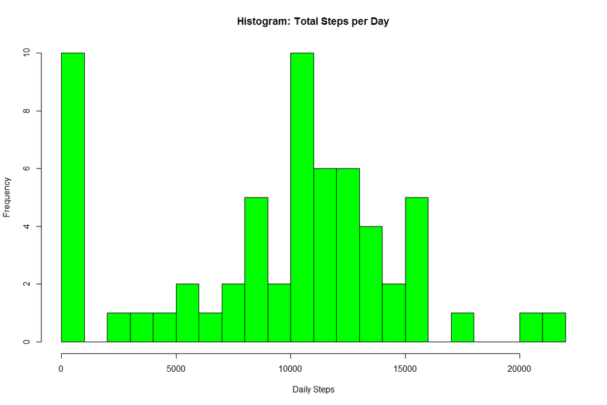

```r
steps_hist<-hist(tot_steps$steps,breaks=16,main="Histogram: Total Steps per Day", xlab="Daily Steps", col="green")
```

```r
steps_hist
```

[output not shown]

3. Calculate and report the mean and median of the total number of steps taken per day

```r
mean(tot_steps$steps)
```

```
## [1] 9354.23
```

```r
median(tot_steps$steps)
```

```
## [1] 10395
```

# Part 3: What is the average daily activity pattern?

1. Make a time series plot (i.e. type = “l”) of the 5-minute interval (x-axis) and the average number of steps taken, averaged across all days (y-axis)

```r
by_interval<-group_by(am_data,interval)
ave_steps<-summarise(by_interval, mean(steps, na.rm = TRUE))
names(ave_steps)[2]<-"steps"

#Values are low because many entries are zeros

head(ave_steps)
```

```
## Source: local data frame [6 x 2]
##
##   interval     steps
##      (int)     (dbl)
## 1        0 1.7169811
## 2        5 0.3396226
## 3       10 0.1320755
## 4       15 0.1509434
## 5       20 0.0754717
## 6       25 2.0943396
```

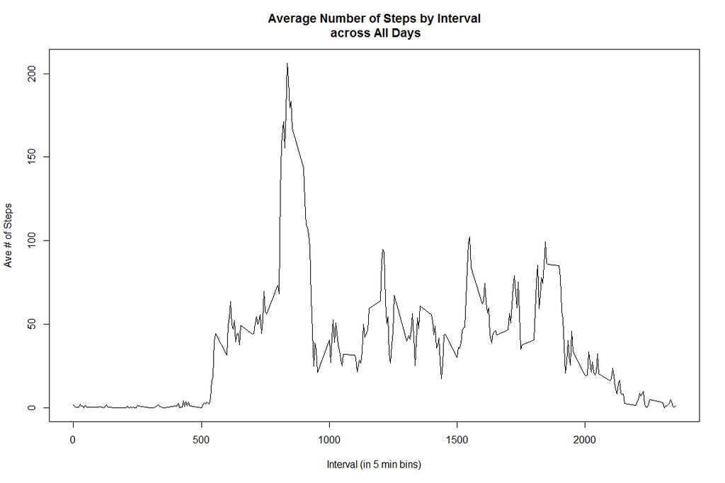

```r
plot(ave_steps$interval, ave_steps$steps, type="l", main="Average Number of Steps by Interval\n across All Days", xlab="Interval (in 5 min bins)", ylab="Ave # of Steps")
```

2. Which 5-minute interval, on average across all the days in the dataset, contains the maximum number of steps?

```r
max_ave<-max(ave_steps$steps)
ave_steps[ave_steps$steps==max_ave,]
```

```
## Source: local data frame [1 x 2]
##
##   interval    steps
##      (int)    (dbl)
## 1      835 206.1698
```

Interval 835 contains the maximum number of steps, the maximum number of steps in that interval is approximately 206.

# Part 4: Imputing missing values

*According to assignment instructions: Note that there are a number of days/intervals where there are missing values (coded as NA).The presence of missing days may introduce bias into some calculations or summaries of the data.*

1. Calculate and report the total number of missing values in the dataset

*(i.e. the total number of rows with NAs)*

```r
sum(is.na(am_data$steps))
```

```
## [1] 2304
```

2. Devise a strategy for filling in all of the missing values in the dataset.

   Strategy: Replace NA’s in dataset with mean number of steps for that interval across all days. These means were calculuated in Part 3. See implementation in the next step.*
3. Create a new dataset that is equal to the original dataset but with the missing data filled in.

   To do this, first filter the data by separating the rows that contain NA’s from the rows not containing NA’s.

```r
filt_data<-filter(am_data,!is.na(am_data$steps))
filt_data2<-filter(am_data,is.na(am_data$steps))

m<-merge(x=filt_data2,y=ave_steps, by="interval")

filt_data2$steps<-m$steps.y

am_data2<-rbind(filt_data,filt_data2)
am_data2<-arrange(am_data2,date,interval)

head(am_data2)
```

```
##      steps       date interval
## 1 1.716981 2012-10-01        0
## 2 1.716981 2012-10-01        5
## 3 1.716981 2012-10-01       10
## 4 1.716981 2012-10-01       15
## 5 1.716981 2012-10-01       20
## 6 1.716981 2012-10-01       25
```

4. Make a histogram of the total number of steps taken each day and

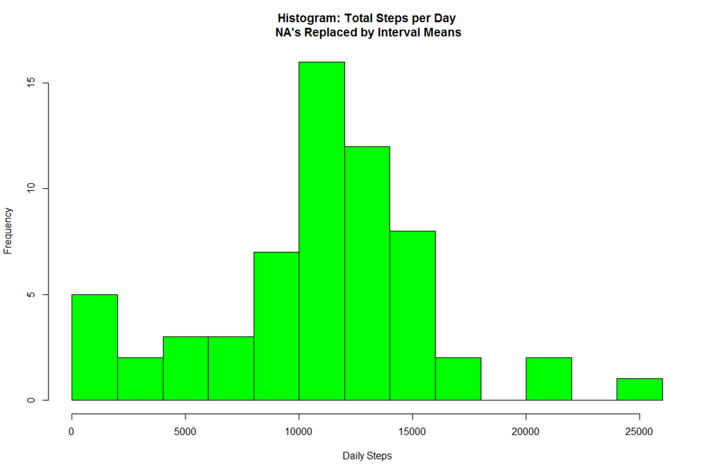

```r
by_date2<-group_by(am_data2,date)
tot_steps2<-summarise(by_date2,sum(steps, na.rm=TRUE))
names(tot_steps2)[2]<-"steps"

steps_hist2<-hist(tot_steps2$steps,breaks=16,main="Histogram: Total Steps per Day\n NA's Replaced by Interval Means", xlab="Daily Steps", col="green")
```

```r
steps_hist2
```

[output not shown]

5. Calculate and report the mean and median total number of steps taken per day.

```r
#These are for the modified dataset.
mean(tot_steps2$steps)
```

```
## [1] 10766.19
```

```r
median(tot_steps2$steps)
```

```
## [1] 11015
```

```r
#These are for the original dataset.
mean(tot_steps$steps)
```

```
## [1] 9354.23
```

```r
median(tot_steps$steps)
```

```
## [1] 10395
```

6. Do these values differ from the estimates from the first part of the assignment? What is the impact of imputing missing data on the estimates of the total daily number of steps?

Yes, the mean and median of the modified data are both greather than those of the original data. By replacing the “NA’s” with estimates based on the means for each interval, the total number of steps taken on any given day that had “NA’s” will increase. Therefore, the mean across all days will increase. Likewise, the median.

# Part 5: Are there differences in activity patterns between weekdays and weekends?

*Use the dataset with the filled-in missing values for this part.*

1. Create a new factor variable in the dataset with two levels - “weekday” and “weekend” indicating whether a given date is a weekday or weekend day.

*Note: Questions 1 & 2 are coded together here.*

-First, the day of the week is derived from the date and added as a new column to the data.Then the data is filtered into a “weekend” set and a “weekday” set. A new column is appended to each set labeling the days as “weeknd” or “weekday”. Then the data is recombined into a single dataset called wk_data.

-Next, the mean steps per interval are computed as previously, but this time the data is grouped by interval and by day_type (weekend or weekday).

-The “day_type” is recast as a factor.

```r
weekday_data<-mutate(am_data2,day=weekdays(date))
wkend<-filter(weekday_data,day=="Saturday"|day=="Sunday")
wkday<-filter(weekday_data,!day=="Saturday"&!day=="Sunday")
wkend<-mutate(wkend,day_type="Weekend")
wkday<-mutate(wkday,day_type="Weekday")

wk_data<-rbind(wkend,wkday)
wk_data<-arrange(wk_data,date,interval)


by_interval2<-group_by(wk_data,interval,day_type)
ave_steps2<-summarise(by_interval2, mean(steps, na.rm = TRUE))
names(ave_steps2)[3]<-"steps"
head(ave_steps2)
```

```
## Source: local data frame [6 x 3]
## Groups: interval [3]
##
##   interval day_type     steps
##      (int)    (chr)     (dbl)
## 1        0  Weekday  5.437736
## 2        0  Weekend 10.841981
## 3        5  Weekday  3.815514
## 4        5  Weekend 10.841981
## 5       10  Weekday  3.571069
## 6       10  Weekend 10.841981
```

```r
ave_steps2$day_type<-as.factor(ave_steps2$day_type)
```

2. Make a panel plot containing a time series plot (i.e. type = “l”) of the 5-minute interval (x-axis) and the average number of steps taken, averaged across all weekday days or weekend days (y-axis).

*See the README file in the GitHub repository to see an example of what this plot should look like using simulated data.*

The ggplot2 package is used for this. The facets parameter is used to generate plots for “Weekend” and “Weekday”.

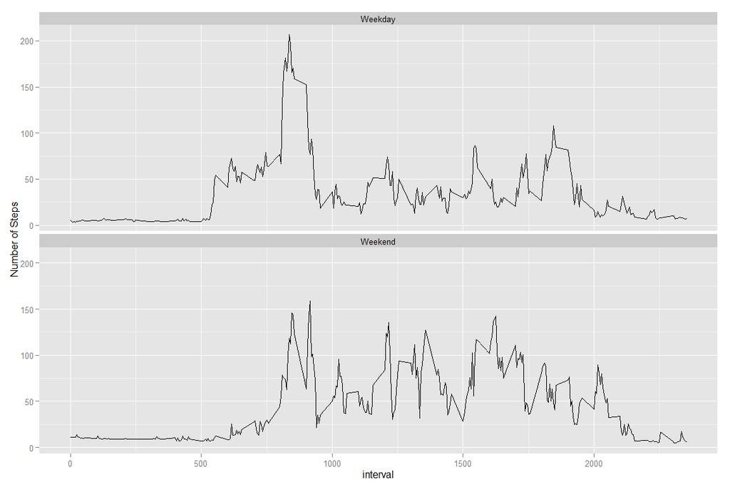

```r
library(ggplot2)
p<-qplot(x=interval,y=steps, data=ave_steps2, geom="line", facet=~day_type, ylab="Number of Steps")

p+facet_wrap(~day_type,nrow=2)
```